# Lecture #5: Centers of Mass & Volumes of Revolution

MATH 146 – Calculus II

Torin Quinlivan

tquinlivan@knox.edu

Knox College

December 23, 2025

## Archimedes’ Law of the Lever

Two magnitudes balance at distances reciprocally proportional to their magnitudes.

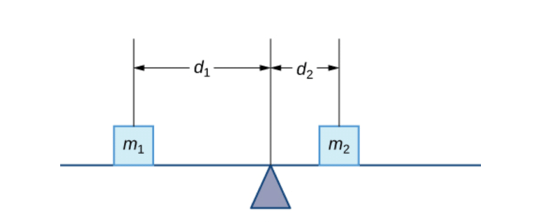

In other words, $\frac{d_1}{d_2} = \frac{m_2}{m_1} \Longleftrightarrow d_1 m_1 = d_2 m_2$.

## Centers of Gravity for Some Elementary 2D Shapes

Archimedes showed that:

- The center of gravity of a parallelogram is the point of intersection of the diagonals.
- The center of gravity of a triangle lies on the straight line between a vertex and the center of the opposite side.
- The center of gravity of a parabolic segment lies at a point $G$ on the diameter of the parabola which is $\frac{3}{5}$ of the way from the vertex to the base.

## Center of Gravity

Given any region bounded by $f(x)$ and $g(x)$, can we find the coordinates $(\overline{x}, \overline{y})$ of its center of gravity?

## The Moment Equation

If masses $m_1, m_2, \dots, m_n$ are suspended on a balance beam from points $x_1, x_2, \dots, x_n$, then the system will be in balance when suspended from the point $\overline{x}$ such that:

$$\sum_{i=1}^n m_i (\overline{x} - x_i) = 0,$$

where:

$$\begin{aligned}
\overline{x} = \dfrac{\displaystyle\sum_{i=1}^n m_i x_i}{\displaystyle\sum_{i=1}^n m_i}.
\end{aligned}$$

## Center of Gravity

$$\begin{aligned}
\overline{x} = \frac{\sum_{i=1}^n m_i x_i}{\sum_{i=1}^n m_i} \quad\Longrightarrow \quad \overline{x}_P = \frac{\sum_{i=1}^n x_i^* (f(x_i^*) - g(x_i^*)) \Delta x_i}{\sum_{i=1}^n (f(x_i^*) - g(x_i^*)) \Delta x_i}
\end{aligned}$$

## Center of Gravity

If we send the width of the intervals to 0, we can rewrite these as intervals.

$$\begin{aligned}
\overline{x}_P &= \lim\limits_{\Delta x \to 0} \frac{\sum_{i=1}^n x_i^* (f(x_i^*) - g(x_i^*)) \Delta x_i}{\sum_{i=1}^n (f(x_i^*) - g(x_i^*)) \Delta x_i} \\[1em]
&= \frac{\displaystyle\int_a^b x\left(f(x) - g(x)\right) \, dx}{\displaystyle\int_a^b f(x) - g(x) \, dx}
\end{aligned}$$

## Center of Gravity

$$\begin{aligned}
\overline{y} = \frac{\sum_{i=1}^n m_i y_i}{\sum_{i=1}^n m_i} \,\Longrightarrow \, \overline{y}_P = \frac{\sum_{i=1}^n \left( \frac{f(x_i^*) + g(x_i^*)}{2} \right) \left( f(x_i^*) - g(x_i^*) \right) \Delta x_i}{\sum_{i=1}^n (f(x_i^*) - g(x_i^*)) \Delta x_i}
\end{aligned}$$

## Center of Gravity

If we send the width of the intervals to 0, we can rewrite these as intervals.

$$\begin{aligned}
\overline{y}_P &= \lim\limits_{\Delta x \to 0} \frac{\sum_{i=1}^n \left( \frac{f(x_i^*) + g(x_i^*)}{2} \right) \left( f(x_i^*) - g(x_i^*) \right) \Delta x_i}{\sum_{i=1}^n (f(x_i^*) - g(x_i^*)) \Delta x_i} \\[1em]
&= \frac{1}{2} \left( \frac{\displaystyle\int_a^b f(x)^2 - g(x)^2 \, dx}{\displaystyle\int_a^b f(x) - g(x) \, dx} \right)
\end{aligned}$$

## Center of Gravity

If a region $R$ is bounded by the graphs of $f(x) > g(x)$ on the interval $[a, b]$, then the center of gravity of $R$ can be found at the point with coordinates $(\overline{x}, \overline{y})$, where:

$$\begin{aligned}
\overline{x} &= \frac{\displaystyle\int_a^b x\left(f(x) - g(x)\right) \, dx}{\displaystyle\int_a^b f(x) - g(x) \, dx} \\[0.5em]
\overline{y} &= \frac{\displaystyle\int_a^b f(x)^2 - g(x)^2 \, dx}{2 \displaystyle\int_a^b f(x) - g(x) \, dx}
\end{aligned}$$

## Example: Center of Gravity

**Example:** Find the center of gravity of the region bounded by the curves $y=1$ and $y=x^2$.

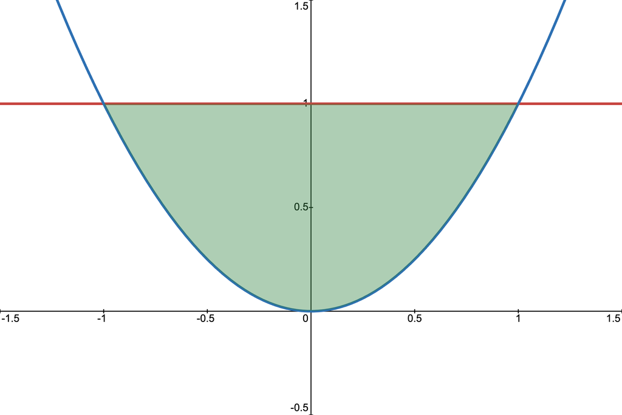

## Example: Center of Gravity

**Example:** Find the center of gravity of the region bounded by the curves $y=\sqrt{x}$ and $y=x^3$.

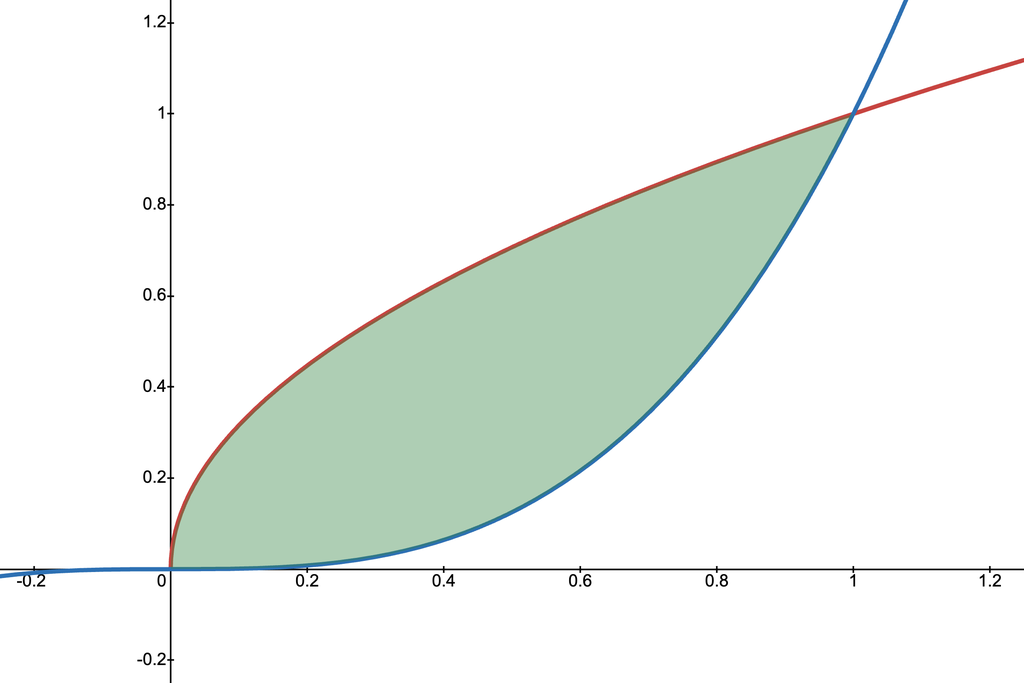

## Volume of Revolution

Given a curve $f(x) \ge 0$ over the interval $[a, b]$, a volume of revolution is the 3D figure obtained by revolving the region between $f(x)$ and the $x$-axis about an axis.

## Volume of Revolution

**Example:** $f(x) = \sin(x)$ on the interval $x \in [0, \pi]$.

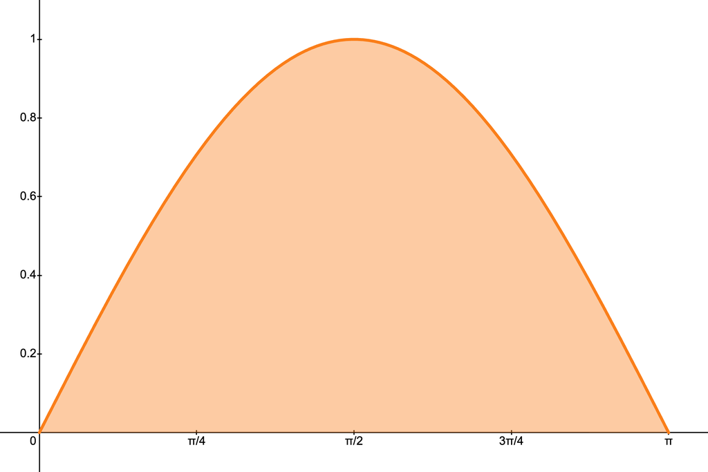

How do we calculate the volume of these?

## Volume of Revolution

[interactive chart not shown]

## Volume of Revolution

[interactive chart not shown]

## The Pappus-Guldin Theorem

Let $R$ be a plane region that lies entirely on one side of a line $l$ in the plane. If $R$ is rotated about $l$, then the volume of the resulting solid is the product of the area $A$ of $R$ and the distance traveled by the centroid of $R$.

## The Disk/Washer Method

Suppose $f(x) \ge g(x) \ge 0$ over an interval $[a, b]$. Then the volume of revolution obtained by rotating the region contained by $f(x)$ and $g(x)$ over the interval $[a,b]$ around the $x$–axis is:

$$V = \pi \int_a^b f(x)^2 - g(x)^2 \, dx$$

$$\begin{aligned}
V &= (2 \pi \overline{y}) \times A_R \\
&= 2\pi \left( \frac{\displaystyle\int_a^b f(x)^2 - g(x)^2 \, dx}{2 \displaystyle\int_a^b f(x) - g(x) \, dx} \right) \left( \int_a^b f(x) - g(x) \, dx \right)
\end{aligned}$$

## Example: The Disk/Washer Method

**Example:** Find the volume of revolution obtained by revolving the region beneath the curve $y = x^2$ around the $x$–axis with $0 \le x \le 1$.

**Example:** Find the volume of revolution obtained by revolving the region beneath the curves $y = x^2$ and $y = 1$ around the $x$–axis with $0 \le x \le 1$.

## The Shell Method

Suppose $f(x) \ge g(x) \ge 0$ over an interval $[a, b]$. Then the volume of revolution obtained by rotating the region contained by $f(x)$ and $g(x)$ over the interval $[a,b]$ around the $y$–axis is:

$$V = 2\pi \int_a^b x \left( f(x) - g(x) \right) \, dx$$

$$\begin{aligned}
V &= (2 \pi \overline{x}) \times A_R \\
&= 2\pi \left( \frac{\displaystyle\int_a^b x\left(f(x) - g(x)\right) \, dx}{\displaystyle\int_a^b f(x) - g(x) \, dx} \right) \left( \int_a^b f(x) - g(x) \, dx \right)
\end{aligned}$$

## Example: The Shell Method

**Example:** Find the volume of revolution obtained by revolving the region beneath the curves $y = x^2$ and $y = 1$ around the $y$–axis with $0 \le x \le 1$.